# UFC Analysis: Does Stance Influence Success?

Santiago Freile

May 2025

## Introduction

Fighters in the UFC adopt different stances — Orthodox, Southpaw, Switch, or Open — that are believed to shape their fighting style. This analysis investigates whether stance significantly influences competitive success. The central question is whether stance actually matters, or whether something else drives wins.

## Dataset

The dataset was sourced from Kaggle and contains fighter statistics including physical attributes and performance metrics such as significant strikes, takedowns, and submissions.

```r
df <- read.csv("~/Desktop/Me/Linfield/2nd Semester/Data 299/Project UFC/ufc.csv")
colnames(df)
```

```
##  [1] "name"
##  [2] "nickname"
##  [3] "wins"
##  [4] "losses"
##  [5] "draws"
##  [6] "height_cm"
##  [7] "weight_in_kg"
##  [8] "reach_in_cm"
##  [9] "stance"
## [10] "date_of_birth"
## [11] "significant_strikes_landed_per_minute"
## [12] "significant_striking_accuracy"
## [13] "significant_strikes_absorbed_per_minute"
## [14] "significant_strike_defence"
## [15] "average_takedowns_landed_per_15_minutes"
## [16] "takedown_accuracy"
## [17] "takedown_defense"
## [18] "average_submissions_attempted_per_15_minutes"
```

```r
glimpse(df)
```

```
## Rows: 4,111
## Columns: 18
## $ name                                         <chr> "Robert Drysdale", "Danie…
## $ nickname                                     <chr> "", "The Animal", "", "",…
## $ wins                                         <int> 7, 15, 13, 7, 8, 9, 5, 4,…
## $ losses                                       <int> 0, 37, 9, 4, 2, 7, 7, 7, …
## $ draws                                        <int> 0, 0, 0, 0, 0, 0, 1, 0, 0…
## $ height_cm                                    <dbl> 190.50, 185.42, 177.80, 1…
## $ weight_in_kg                                 <dbl> 92.99, 83.91, 97.98, 61.2…
## $ reach_in_cm                                  <dbl> NA, NA, NA, NA, 193.04, N…
## $ stance                                       <chr> "Orthodox", "", "", "", "…
## $ date_of_birth                                <chr> "1981-10-05", "", "", "",…
## $ significant_strikes_landed_per_minute        <dbl> 0.00, 3.36, 0.00, 1.40, 2…
## $ significant_striking_accuracy                <dbl> 0, 77, 0, 33, 60, 0, 50, …
## $ significant_strikes_absorbed_per_minute      <dbl> 0.00, 0.00, 5.58, 1.40, 2…
## $ significant_strike_defence                   <dbl> 0, 0, 60, 75, 42, 38, 80,…
## $ average_takedowns_landed_per_15_minutes      <dbl> 7.32, 0.00, 0.00, 0.00, 1…
## $ takedown_accuracy                            <dbl> 100, 0, 0, 0, 100, 0, 0, …
## $ takedown_defense                             <dbl> 0, 100, 0, 100, 0, 0, 66,…
## $ average_submissions_attempted_per_15_minutes <dbl> 21.9, 21.6, 20.9, 20.9, 2…
```

## Data Cleaning

The dataset is filtered to relevant columns and cleaned of missing stance values. Win percentage is calculated as wins divided by total matches, providing a normalized measure of success regardless of career length.

```r
df2 <- df |>
  select(name, stance, wins, losses, draws,
         significant_strikes_landed_per_minute,
         significant_strikes_absorbed_per_minute,
         significant_strike_defence,
         average_takedowns_landed_per_15_minutes,
         average_submissions_attempted_per_15_minutes,
         takedown_defense) |>
  filter(!is.na(stance), stance != "")

df2$stance <- as.factor(df2$stance)

df2 <- df2 |>
  mutate(
    total_matches = wins + losses + draws,
    win_percentage = wins / total_matches
  )
```

## Stance

### Fighter Stance Distribution

Orthodox is by far the most common stance, followed by Southpaw and Switch. Open Stance and Sideways are rare enough that conclusions about those categories should be interpreted carefully given the smaller sample sizes.

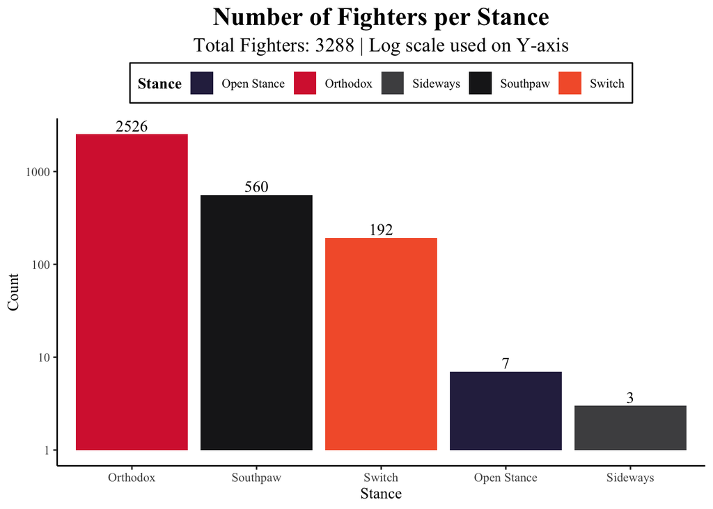

```r
df2 |>
  count(stance) |>
  ggplot(aes(x = reorder(stance, -n), y = n, fill = stance)) +
  geom_bar(stat = "identity", show.legend = TRUE) +
  geom_text(aes(label = n), vjust = -0.3, size = 4, family = "Times New Roman") +
  scale_y_log10() +
  labs(
    title = "Number of Fighters per Stance",
    subtitle = paste("Total Fighters:", sum(df2$stance %in% unique(df2$stance)), "| Log scale used on Y-axis"),
    x = "Stance",
    y = "Count",
    fill = "Stance"
  ) +
  scale_fill_manual(values = c(
    "Orthodox"    = "#D7263D",
    "Southpaw"    = "#1B1B1E",
    "Switch"      = "#F46036",
    "Open Stance" = "#2E294E",
    "Sideways"    = "#4E4E50"
  )) +
  theme_classic(base_family = "Times New Roman") +
  theme(
    plot.title = element_text(size = 18, face = "bold", hjust = 0.5),
    plot.subtitle = element_text(size = 14, hjust = 0.5),
    legend.position = "top",
    legend.background = element_rect(color = "black", fill = "white", size = 0.5),
    legend.title = element_text(face = "bold")
  )
```

### Performance by Stance

Three performance metrics are compared across stances: significant strikes landed per minute, average takedowns per 15 minutes, and significant strike defense. The distributions overlap considerably across stances, suggesting that stance alone does not separate fighters along these dimensions.

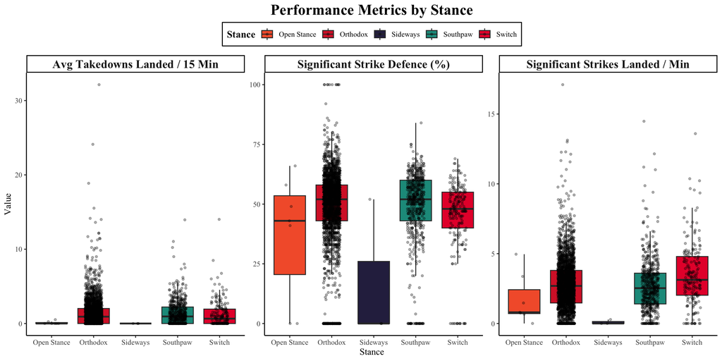

```r
metric_labels <- c(
  significant_strikes_landed_per_minute = "Significant Strikes Landed / Min",
  average_takedowns_landed_per_15_minutes = "Avg Takedowns Landed / 15 Min",
  significant_strike_defence = "Significant Strike Defence (%)"
)

df3 <- df2 |>
  pivot_longer(cols = c(significant_strikes_landed_per_minute,
                        average_takedowns_landed_per_15_minutes,
                        significant_strike_defence),
               names_to = "metric", values_to = "value") |>
  mutate(metric_label = metric_labels[metric])

ggplot(df3, aes(x = stance, y = value, fill = stance)) +
  geom_boxplot(outlier.shape = NA) +
  geom_jitter(width = 0.2, alpha = 0.3, color = "black", size = 1) +
  facet_wrap(~ metric_label, scales = "free_y", ncol = 3) +
  labs(title = "Performance Metrics by Stance",
       x = "Stance", y = "Value", fill = "Stance") +
  scale_fill_manual(values = c(
    "Orthodox" = "#D72631",
    "Open Stance" = "#F46036",
    "Sideways" = "#2E294E",
    "Southpaw" = "#1B998B",
    "Switch" = "#E71D36"
  )) +
  theme_classic(base_family = "Times New Roman") +
  theme(
    plot.title = element_text(size = 18, face = "bold", hjust = 0.5),
    legend.position = "top",
    legend.title = element_text(face = "bold", size = 12),
    legend.background = element_rect(color = "black", size = 0.5, linetype = "solid"),
    strip.text = element_text(size = 14, face = "bold")
  )
```

### Wins by Stance

Win percentage distributions are similar across stances. The median is roughly consistent, though variance differs. The smaller stances like Sideways and Open Stance show more erratic distributions, which is a function of sample size rather than stance effectiveness.

```r
plot4 <- df2 |>
  ggplot(aes(x = stance, y = win_percentage, fill = stance)) +
  geom_boxplot(width = 0.8) +
  coord_flip() +
  labs(
    title = "Win Percentage by Fighter Stance",
    x = "Stance",
    y = "Win Percentage",
    fill = "Stance") +
  scale_y_continuous(labels = scales::percent_format(accuracy = 1)) +
  scale_fill_manual(values = c(
    "Orthodox" = "#D72631",
    "Open Stance" = "#F46036",
    "Sideways" = "#2E294E",
    "Southpaw" = "#1B998B",
    "Switch" = "#E71D36"
  )) +
  theme_classic(base_family = "Times New Roman") +
  theme(
    plot.title = element_text(size = 18, face = "bold", hjust = 0.5),
    legend.position = "top",
    legend.title = element_text(face = "bold", size = 12),
    legend.background = element_rect(color = "black", size = 0.5),
    axis.text = element_text(size = 13),
    axis.title = element_text(size = 15),
    strip.text = element_text(size = 14, face = "bold")
  )

ggplotly(plot4)
```

[interactive chart not shown]

## Statistics

### Summary by Stance

```r
stance_summary <- df2 |>
  group_by(stance) |>
  summarise(
    `Number of Fighters` = n(),
    `Win %` = mean(win_percentage, na.rm = TRUE),
    `Avg. Wins` = mean(wins, na.rm = TRUE),
    `Avg. Losses` = mean(losses, na.rm = TRUE),
    `Strikes Landed (per min)` = mean(significant_strikes_landed_per_minute, na.rm = TRUE),
    `Strikes Absorbed (per min)` = mean(significant_strikes_absorbed_per_minute, na.rm = TRUE),
    `Strike Defense (%)` = mean(significant_strike_defence, na.rm = TRUE),
    `Takedowns (per 15 min)` = mean(average_takedowns_landed_per_15_minutes, na.rm = TRUE),
    `Submission Attempts (per 15 min)` = mean(average_submissions_attempted_per_15_minutes, na.rm = TRUE),
    `Takedown Defense (%)` = mean(takedown_defense, na.rm = TRUE)
  )

stance_summary |>
  mutate(
    `Win %` = scales::percent(`Win %`, accuracy = 0.1),
  ) |>
  kable(caption = "Summary Stats by Fighter Stance", digits = 2) |>
  kable_styling()
```

Summary Stats by Fighter Stance

| stance | Number of Fighters | Win % | Avg. Wins | Avg. Losses | Strikes Landed (per min) | Strikes Absorbed (per min) | Strike Defense (%) | Takedowns (per 15 min) | Submission Attempts (per 15 min) | Takedown Defense (%) |
| --- | --- | --- | --- | --- | --- | --- | --- | --- | --- | --- |
| Open Stance | 7 | 57.5% | 15.29 | 9.86 | 1.72 | 2.00 | 36.71 | 0.11 | 0.14 | 28.14 |
| Orthodox | 2526 | 67.6% | 13.43 | 6.01 | 2.77 | 3.61 | 48.31 | 1.40 | 0.64 | 44.69 |
| Sideways | 3 | 38.9% | 2.00 | 1.67 | 0.09 | 0.47 | 17.33 | 0.00 | 2.83 | 0.00 |
| Southpaw | 560 | 68.3% | 14.63 | 6.35 | 2.70 | 3.30 | 48.57 | 1.40 | 0.64 | 44.76 |
| Switch | 192 | 73.7% | 11.48 | 4.27 | 3.48 | 3.93 | 44.99 | 1.27 | 0.60 | 47.47 |

### Win Percentage Variability

```r
stance_summary2 <- df2 |>
  group_by(stance) |>
  summarise(
    count = n(),
    avg_win_percentage = round(mean(win_percentage, na.rm = TRUE), 3),
    sd_win_percentage = round(sd(win_percentage, na.rm = TRUE), 3)
  )

stance_summary2 |>
  mutate(
    avg_win_percentage = scales::percent(avg_win_percentage, accuracy = 0.1),
    sd_win_percentage = scales::percent(sd_win_percentage, accuracy = 0.1)
  ) |>
  kable(caption = "Summary of Win Percentage by Stance") |>
  kable_styling(bootstrap_options = c("striped", "hover"), full_width = FALSE, position = "left")
```

Summary of Win Percentage by Stance

| stance | count | avg_win_percentage | sd_win_percentage |
| --- | --- | --- | --- |
| Open Stance | 7 | 57.5% | 16.3% |
| Orthodox | 2526 | 67.6% | 17.5% |
| Sideways | 3 | 38.9% | 34.7% |
| Southpaw | 560 | 68.3% | 16.5% |
| Switch | 192 | 73.7% | 13.6% |

### t-test: Orthodox vs Southpaw

```r
df_subset <- df2 |> filter(stance %in% c("Orthodox", "Southpaw"))

t_test_result <- t.test(win_percentage ~ stance, data = df_subset, alternative = "two.sided")

t_test_result
```

```
##
##  Welch Two Sample t-test
##
## data:  win_percentage by stance
## t = -0.89714, df = 860.06, p-value = 0.3699
## alternative hypothesis: true difference in means between group Orthodox and group Southpaw is not equal to 0
## 95 percent confidence interval:
##  -0.022272762  0.008298789
## sample estimates:
## mean in group Orthodox mean in group Southpaw
##              0.6757904              0.6827774
```

```r
cat("95% confidence interval for the difference in mean win percentages:\n")
```

```
## 95% confidence interval for the difference in mean win percentages:
```

```r
cat(sprintf("[%.3f, %.3f]\n", t_test_result$conf.int[1], t_test_result$conf.int[2]))
```

```
## [-0.022, 0.008]
```

The 95% confidence interval for the difference in win percentages between Orthodox and Southpaw fighters is [-0.022, 0.008]. Since this interval includes zero, there is no statistically significant difference between the two stances.

## Linear Models

### Model 1: Wins ~ Stance

```r
model1 <- lm(wins ~ stance, data = df2)
summary(model1)
```

```
##
## Call:
## lm(formula = wins ~ stance, data = df2)
##
## Residuals:
##     Min      1Q  Median      3Q     Max
## -14.627  -5.427  -1.427   3.573 239.573
##
## Coefficients:
##                Estimate Std. Error t value Pr(>|t|)
## (Intercept)     15.2857     3.5770   4.273 1.98e-05 ***
## stanceOrthodox  -1.8590     3.5820  -0.519    0.604
## stanceSideways -13.2857     6.5307  -2.034    0.042 *
## stanceSouthpaw  -0.6589     3.5993  -0.183    0.855
## stanceSwitch    -3.8013     3.6416  -1.044    0.297
## ---
## Signif. codes:  0 '***' 0.001 '**' 0.01 '*' 0.05 '.' 0.1 ' ' 1
##
## Residual standard error: 9.464 on 3283 degrees of freedom
## Multiple R-squared:  0.006498,   Adjusted R-squared:  0.005288
## F-statistic: 5.368 on 4 and 3283 DF,  p-value: 0.0002626
```

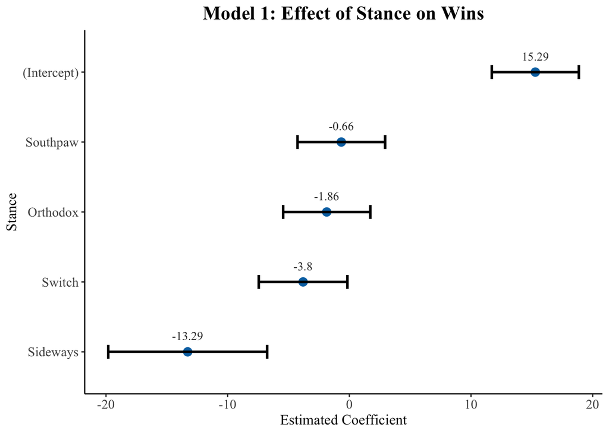

```r
tidy1 <- tidy(model1)
tidy1$term <- gsub("stance", "", tidy1$term)

ggplot(tidy1, aes(x = reorder(term, estimate), y = estimate)) +
  geom_point(color = "#0072B2", size = 3) +
  geom_errorbar(aes(ymin = estimate - std.error, ymax = estimate + std.error),
                width = 0.2, size = 1) +
  geom_text(aes(label = round(estimate, 2)),
            vjust = -1.5,
            family = "Times New Roman", size = 3.5, color = "gray20") +
  theme_classic(base_family = "Times New Roman") +
  coord_flip() +
  labs(title = "Model 1: Effect of Stance on Wins",
       x = "Stance",
       y = "Estimated Coefficient") +
  theme(plot.title = element_text(size = 16, face = "bold", hjust = 0.5),
        axis.text = element_text(size = 11),
        axis.title = element_text(size = 12))
```

Stance alone is not a meaningful predictor of wins. The model is technically significant (p = 0.00026) but explains only 0.65% of the variance in wins (R² = 0.0065). The Sideways stance shows a marginally significant negative coefficient (p = 0.042), but given the model’s weak explanatory power, this is unlikely to reflect anything practically meaningful.

### Model 2: Wins ~ Stance + Performance Metrics

```r
model2 <- lm(wins ~ stance +
               significant_strikes_landed_per_minute +
               significant_strikes_absorbed_per_minute +
               significant_strike_defence +
               average_takedowns_landed_per_15_minutes +
               average_submissions_attempted_per_15_minutes +
               takedown_defense, data = df2)
summary(model2)
```

```
##
## Call:
## lm(formula = wins ~ stance + significant_strikes_landed_per_minute +
##     significant_strikes_absorbed_per_minute + significant_strike_defence +
##     average_takedowns_landed_per_15_minutes + average_submissions_attempted_per_15_minutes +
##     takedown_defense, data = df2)
##
## Residuals:
##     Min      1Q  Median      3Q     Max
## -17.254  -5.380  -1.506   3.510 244.067
##
## Coefficients:
##                                               Estimate Std. Error t value
## (Intercept)                                   11.89213    3.50032   3.397
## stanceOrthodox                                -2.95928    3.49092  -0.848
## stanceSideways                               -12.06928    6.36656  -1.896
## stanceSouthpaw                                -1.86895    3.50729  -0.533
## stanceSwitch                                  -4.54205    3.54996  -1.279
## significant_strikes_landed_per_minute         -0.13445    0.10480  -1.283
## significant_strikes_absorbed_per_minute       -0.24632    0.06310  -3.904
## significant_strike_defence                     0.08417    0.01094   7.691
## average_takedowns_landed_per_15_minutes       -0.05360    0.08939  -0.600
## average_submissions_attempted_per_15_minutes   0.29877    0.12169   2.455
## takedown_defense                               0.03521    0.00563   6.253
##                                              Pr(>|t|)
## (Intercept)                                  0.000688 ***
## stanceOrthodox                               0.396663
## stanceSideways                               0.058084 .
## stanceSouthpaw                               0.594156
## stanceSwitch                                 0.200825
## significant_strikes_landed_per_minute        0.199597
## significant_strikes_absorbed_per_minute      9.66e-05 ***
## significant_strike_defence                   1.92e-14 ***
## average_takedowns_landed_per_15_minutes      0.548823
## average_submissions_attempted_per_15_minutes 0.014130 *
## takedown_defense                             4.54e-10 ***
## ---
## Signif. codes:  0 '***' 0.001 '**' 0.01 '*' 0.05 '.' 0.1 ' ' 1
##
## Residual standard error: 9.209 on 3277 degrees of freedom
## Multiple R-squared:  0.06092,    Adjusted R-squared:  0.05806
## F-statistic: 21.26 on 10 and 3277 DF,  p-value: < 2.2e-16
```

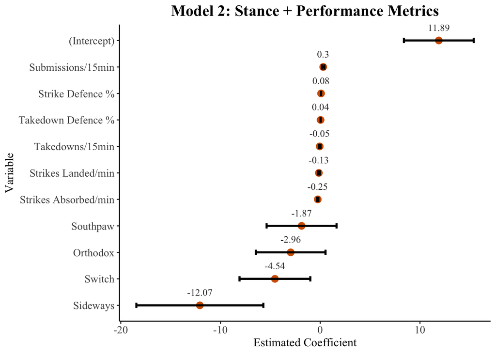

```r
tidy2 <- tidy(model2)
tidy2 <- tidy2 |>
  mutate(term = case_when(
    term == "stanceOrthodox" ~ "Orthodox",
    term == "stanceSouthpaw" ~ "Southpaw",
    term == "stanceSwitch" ~ "Switch",
    term == "stanceSideways" ~ "Sideways",
    term == "significant_strikes_landed_per_minute" ~ "Strikes Landed/min",
    term == "significant_strikes_absorbed_per_minute" ~ "Strikes Absorbed/min",
    term == "significant_strike_defence" ~ "Strike Defence %",
    term == "average_takedowns_landed_per_15_minutes" ~ "Takedowns/15min",
    term == "average_submissions_attempted_per_15_minutes" ~ "Submissions/15min",
    term == "takedown_defense" ~ "Takedown Defence %",
    TRUE ~ term
  ))

ggplot(tidy2, aes(x = reorder(term, estimate), y = estimate)) +
  geom_point(color = "#D55E00", size = 3) +
  geom_errorbar(aes(ymin = estimate - std.error, ymax = estimate + std.error),
                width = 0.2, size = 1) +
  geom_text(aes(label = round(estimate, 2)),
            vjust = -1.5,
            family = "Times New Roman", size = 3.5, color = "gray20") +
  theme_classic(base_family = "Times New Roman") +
  coord_flip() +
  labs(title = "Model 2: Stance + Performance Metrics",
       x = "Variable",
       y = "Estimated Coefficient") +
  theme(plot.title = element_text(size = 16, face = "bold", hjust = 0.5),
        axis.text = element_text(size = 11),
        axis.title = element_text(size = 12))
```

Adding performance metrics improves explanatory power to 6.1% (R² = 0.061). Stance remains insignificant. Strike defense (p < 0.001), takedown defense (p < 0.001), and submission attempts (p = 0.014) are the significant predictors. Strikes absorbed per minute has a significant negative effect, meaning taking more damage correlates with fewer wins.

### Model 3: Wins ~ Performance Metrics Only

```r
model3 <- lm(wins ~ significant_strikes_landed_per_minute +
               significant_strikes_absorbed_per_minute +
               significant_strike_defence +
               average_takedowns_landed_per_15_minutes +
               average_submissions_attempted_per_15_minutes +
               takedown_defense, data = df2)
summary(model3)
```

```
##
## Call:
## lm(formula = wins ~ significant_strikes_landed_per_minute + significant_strikes_absorbed_per_minute +
##     significant_strike_defence + average_takedowns_landed_per_15_minutes +
##     average_submissions_attempted_per_15_minutes + takedown_defense,
##     data = df2)
##
## Residuals:
##     Min      1Q  Median      3Q     Max
## -17.595  -5.384  -1.526   3.552 244.029
##
## Coefficients:
##                                              Estimate Std. Error t value
## (Intercept)                                   8.97092    0.53554  16.751
## significant_strikes_landed_per_minute        -0.16353    0.10441  -1.566
## significant_strikes_absorbed_per_minute      -0.24936    0.06312  -3.950
## significant_strike_defence                    0.08740    0.01091   8.007
## average_takedowns_landed_per_15_minutes      -0.05121    0.08949  -0.572
## average_submissions_attempted_per_15_minutes  0.28209    0.12175   2.317
## takedown_defense                              0.03515    0.00564   6.232
##                                              Pr(>|t|)
## (Intercept)                                   < 2e-16 ***
## significant_strikes_landed_per_minute          0.1174
## significant_strikes_absorbed_per_minute      7.97e-05 ***
## significant_strike_defence                   1.62e-15 ***
## average_takedowns_landed_per_15_minutes        0.5672
## average_submissions_attempted_per_15_minutes   0.0206 *
## takedown_defense                             5.19e-10 ***
## ---
## Signif. codes:  0 '***' 0.001 '**' 0.01 '*' 0.05 '.' 0.1 ' ' 1
##
## Residual standard error: 9.227 on 3281 degrees of freedom
## Multiple R-squared:  0.05614,    Adjusted R-squared:  0.05441
## F-statistic: 32.52 on 6 and 3281 DF,  p-value: < 2.2e-16
```

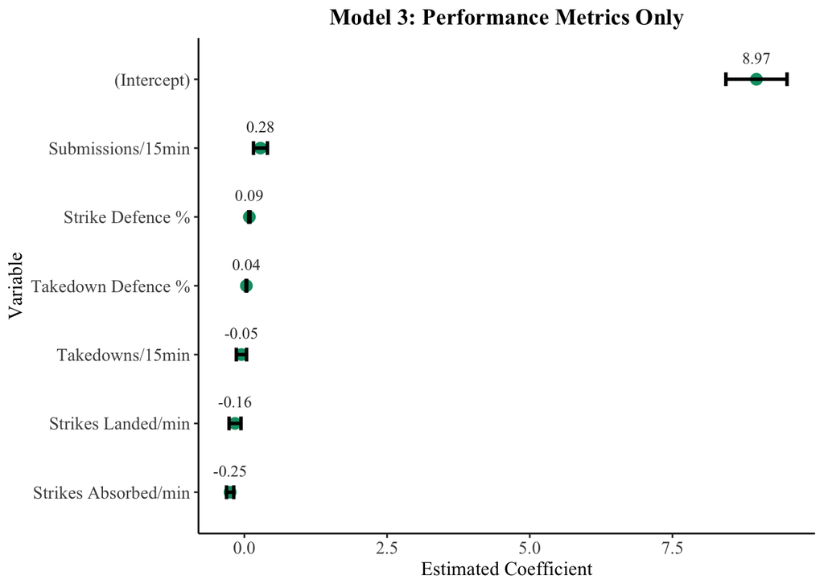

```r
tidy3 <- tidy(model3)
tidy3 <- tidy3 |>
  mutate(term = case_when(
    term == "significant_strikes_landed_per_minute" ~ "Strikes Landed/min",
    term == "significant_strikes_absorbed_per_minute" ~ "Strikes Absorbed/min",
    term == "significant_strike_defence" ~ "Strike Defence %",
    term == "average_takedowns_landed_per_15_minutes" ~ "Takedowns/15min",
    term == "average_submissions_attempted_per_15_minutes" ~ "Submissions/15min",
    term == "takedown_defense" ~ "Takedown Defence %",
    TRUE ~ term
  ))

ggplot(tidy3, aes(x = reorder(term, estimate), y = estimate)) +
  geom_point(color = "#009E73", size = 3) +
  geom_errorbar(aes(ymin = estimate - std.error, ymax = estimate + std.error),
                width = 0.2, size = 1) +
  geom_text(aes(label = round(estimate, 2)),
            vjust = -1.5,
            family = "Times New Roman", size = 3.5, color = "gray20") +
  coord_flip() +
  theme_classic(base_family = "Times New Roman") +
  labs(title = "Model 3: Performance Metrics Only",
       x = "Variable",
       y = "Estimated Coefficient") +
  theme(
    plot.title = element_text(hjust = 0.5, size = 14, face = "bold"),
    axis.text = element_text(size = 11),
    axis.title = element_text(size = 12)
  )
```

Removing stance from the model barely changes the results (R² = 0.056 vs 0.061). The same defensive metrics remain significant. This confirms that stance adds essentially no predictive value once performance is accounted for.

## References

1. Kaggle (2024). UFC Fighters’ Statistics Dataset. https://www.kaggle.com/datasets/aaronfriasr/ufc-fighters-statistics/data
2. Ultimate Fighting Championship. https://www.ufc.com
3. Coolors: Color Palette Generator. https://coolors.co